# eDNA-analysis

Meron G. Tekle

2024-06-04

# This is the rmarkdown document for analysing environmental samples

### Load required packages for the analysis

```r
library(tidyverse)
library(qiime2R)
library(microbiome)
library(phyloseq)
library(stringr)
library(forcats)
library(reshape2)
```

```r
library(ggraph)
library(igraph)
library(tidygraph)
library(ggalt)
library(vegan)
```

# Importing our data from qiime2 output

### Import .qza files from qiime2 into R using the qiime2R package and create a phyloseq object

```r
physeq <- qza_to_phyloseq(
  features = "../qiime_outputs/table.qza",
  tree = "../qiime_outputs/rooted_tree.qza",
  "../qiime_outputs/blast-taxonomy-results-97.qza",
  metadata = "../qiime_outputs/sample-metadata.txt")
```

### use the microbiome package to create tible files for feature table and taxonomy table which will be merged later to make analysis easier down the road

```r
otu.tib <- otu_tibble(physeq, column.id = "FeatureID") #retrieves our feature table
tax.tib <- tax_tibble(physeq, column.id = "FeatureID") #retrieves our taxonomic assignment table
sample_tib <- sample_tibble(physeq, column.id = "SampleID") #retrieves our sample metadata
```

### Then we will merge all these tables using shared columns such as “SampleID” and “featureID”

```r
dat <- otu.tib %>%
  pivot_longer(-FeatureID, names_to = "SampleID", values_to = "count") #creates a file with the columns FeatureID (ASV id given by qiime), SampleID (Sample names) and Count(abundance of a feature inside a sample). Now it is easier to join with other tables
```

### Use left_join to add taxa table, metadata

```r
dat <- dat %>%
  left_join(tax.tib, by="FeatureID")

dat <- dat %>%
  left_join(sample_tib, by = "SampleID")

#dat
```

### Now to we add shannon index and PCoA results to the data table, but first we import both shannon and PCoA results

```r
shannon <- read_qza("../qiime_outputs/shannon_vector.qza") #import from qiime using qiime2R

shannon <- shannon$data %>% rownames_to_column("SampleID") #make it easier to merge to "dat" using "SampleID"

dat <- dat %>%
  left_join(shannon, by = "SampleID")

#dat
```

### We also add a column for observed features

```r
obs_feat <- read_qza("../qiime_outputs/observed_features_vector.qza") #import from qiime using qiime2R

obs_feat <- obs_feat$data %>% rownames_to_column("SampleID") #make it easier to merge to "dat" using "SampleID"

dat <- dat %>%
  left_join(obs_feat, by = "SampleID")

#dat
```

### Now we do the same with PCoA results

```r
uwunifrac<-read_qza("../qiime_outputs/unweighted_unifrac_pcoa_results.qza") #import unweighted unifrac results from qiime2

unifrac_modify<- uwunifrac$data$Vectors %>%
  select(SampleID, PC1, PC2)  #we select only two dimensions because we cannot effectively show more dimension on paper

dat <- dat %>%
  left_join(unifrac_modify, by = "SampleID")

#dat
```

### Now we remove the accession numbers from our Species names and rename them as ITS2types

```r
dat <- dat %>%
  mutate(ITS2_types= (str_replace_all(pattern = '-.*', replacement = "", Species.x)))
```

# Part II - Analysis - visulaize alpha and beta diversity

## But before we create plots, lets create a custom theme. This will make our code cleaner

```r
my_theme_alpha <-  theme(panel.border = element_rect(colour = "black", fill = NA),
                     panel.background = element_blank(),
                     panel.grid = element_blank(),
                     axis.text  = element_text(size = 10),
                     axis.text.x = element_text(angle = 0),
                     axis.title = element_text(size = 20),
                     strip.background = element_blank(),
                     strip.text = element_text(size = 10),
                     axis.line.x = element_line(size = 0.5),
                     axis.line.y = element_line(size = 0.5),
                     legend.position = "right",
                     legend.text =element_text(size = 5))
```

# Create a Shannon diversity Box Plot

### But before lets create a dataframe with each sample coressponding to a unique sahnnon diversity value

```r
dat_shannon <- dat %>%
  group_by(SampleID, Type, Depth) %>%
  summarise(Richness = unique(shannon_entropy)) %>%
  drop_na(Richness)
#dat_shannon
```

## Plot a shannon boxplot with points for depth

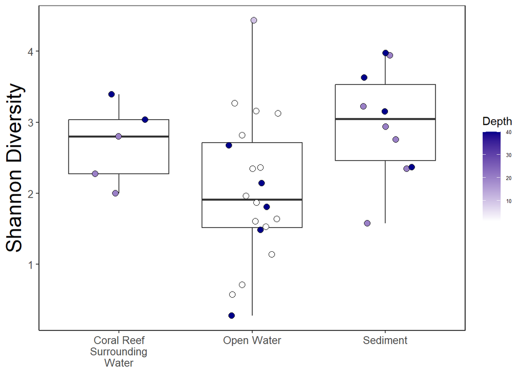

```r
dat_shannon$Type <- factor(dat_shannon$Type, levels = c("Open Water", "Coral Reef Surrounding Water", "Sediment")) #we order the sample to better compare them in the plot

dat_shannon$Type <- str_wrap(dat_shannon$Type, width = 10) #this allows us to wrap long labels

fig3a <- dat_shannon %>%
  drop_na(Richness) %>% #removes values from samples not included in analysis because of sampling depth
  ggplot(aes(Type, Richness)) +
  geom_boxplot(position = "dodge", show.legend = F)+
  geom_jitter(aes(fill = Depth), shape = 21, width=0.2, height = 0, size = 2.5)+
  xlab(NULL)+
  ylab("Shannon Diversity")+
  my_theme_alpha+
  scale_fill_gradient(low = "white", high = "darkblue")+
  my_theme_alpha

fig3a
```

```r
#fig3a <- ggsave("../figures/fig3a.png", height = 4, width = 5, device= "png")
```

## summary statistics for alpha diversity

```r
dat_shannon %>%
  group_by(Type) %>%
  summarize(mean_richness = mean(Richness, na.rm = T))
```

```
## # A tibble: 3 × 2
##   Type                             mean_richness
##   <chr>                                    <dbl>
## 1 "Coral Reef\nSurrounding\nWater"          2.70
## 2 "Open Water"                              2.05
## 3 "Sediment"                                2.99
```

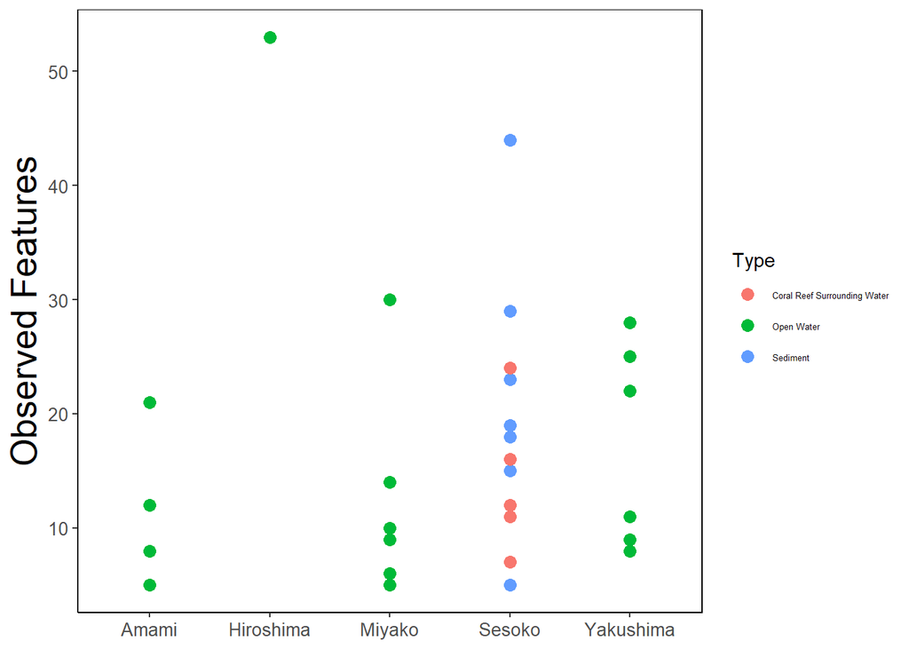

```r
dat_obs <- dat %>%
  filter(!is.na(observed_features)) %>%
  ggplot(aes(Location, observed_features, color = Type)) +
  geom_point(size = 3)+
  xlab(NULL)+
  ylab("Observed Features")+
  my_theme_alpha
  #scale_fill_gradient(low = "white", high = "darkblue")

figure3b <- dat_obs

figure3b
```

```r
fig3b <- ggsave("../figures/figure3b.png", height = 4, width = 5, device= "png")
```

## Create a PCoA ordination based on unweighted unifrac distances

### create a theme for this graph

```r
 my_theme_pcoa <-  theme(panel.border = element_rect(colour = "black", fill = NA),
                     panel.background = element_blank(),
                     panel.grid = element_blank(),
                     axis.text  = element_text(size = 10),
                     axis.text.x = element_text(angle = 0),
                     axis.title = element_text(size = 20),
                     strip.background = element_blank(),
                     strip.text = element_text(size = 10),
                     axis.line.x = element_line(size = 0.5),
                     axis.line.y = element_line(size = 0.5),
                     legend.position = "right",
                     legend.text =element_text(size = 5))
```

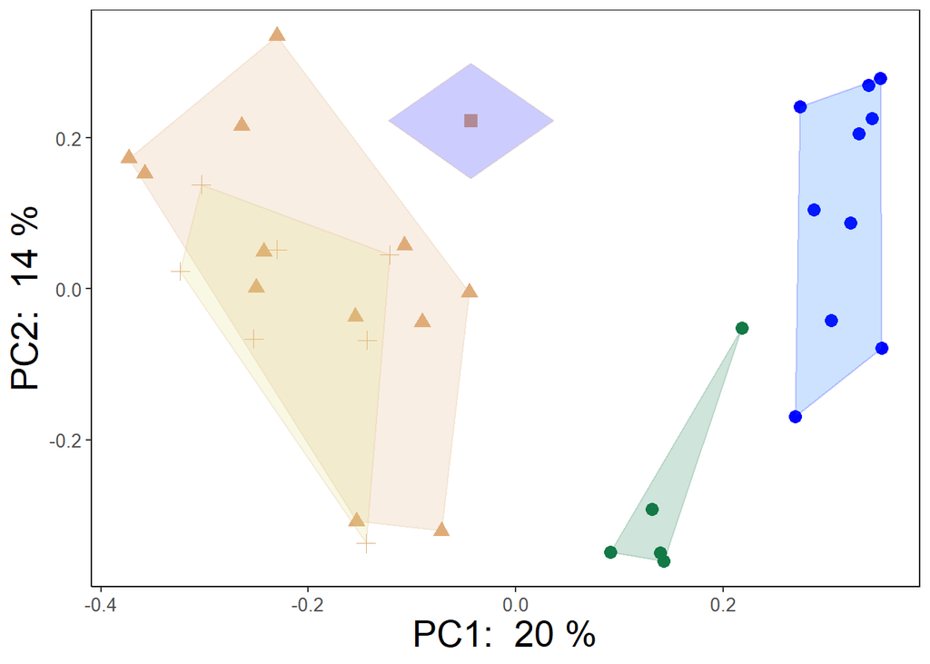

```r
dat_pcoa <- dat

fig4 <- dat_pcoa %>%
  drop_na() %>% #drops na values
  mutate(biomes = fct_relevel(Type, c("Open Water", "Coral Reef Surrounding Water", "Sediment"))) %>%
  mutate(encircle  = paste(biomes, "_", Region)) %>%
  ggplot(aes(x=PC1, y=PC2, color= Type, shape = Region))+
  geom_point(alpha=0.2, size = 3, show.legend = F) +
  geom_encircle(aes(fill = encircle),alpha = 0.2, s_shape = 1, expand  = 0, show.legend = F)+
  xlab(paste("PC1: ", round(100*uwunifrac$dat$ProportionExplained[1]), "%")) +
  ylab(paste("PC2: ", round(100*uwunifrac$data$ProportionExplained[2]), "%"))+
  scale_shape_discrete()+
  scale_color_manual(values = c("#117744", "#DDAA77", "#0000FF", "#DDDD77"))+
  scale_fill_manual(values= c( "#117744", "#DDAA77", "#0000FF", "#DDDD77" , "#0070FF"), name = "Biomes")+
  my_theme_pcoa

fig4
```

```r
#fig4 <- ggsave("../figures/fig4.png", height = 4, width = 5, device= "png")
```

## create a theme for the composition plot

```r
my_theme_bar <-  theme(panel.border = element_rect(colour = "black", fill = NA),
                     panel.background = element_blank(),
                     panel.grid = element_blank(),
                     axis.text  = element_text(size = 8),
                     axis.text.x = element_text(angle = 90, face = "italic"),
                     axis.text.x.top = element_text(size=5),
                     axis.title = element_text(size = 20),
                     strip.background = element_blank(),
                     strip.text = element_text(size = 10),
                     axis.line.x = element_line(size = 0.5),
                     axis.line.y = element_line(size = 0.5),
                     legend.position = "right",
                     legend.text =element_text(size =8, face = "italic"))
```

## create a composition plot by genus

### But first lets order the names and plot the 10 most observed symbiont genera, because we are not good with colors

```r
total_top_counts <- dat %>% #summarize and arrange the total count of each genus across all samples
  group_by(Genus.x) %>%
  summarize(total_top_counts = sum(count)) %>%
  arrange(desc(total_top_counts))

top_10_genus <- total_top_counts %>% #get the 10 most abundant genus by count
  top_n(10,wt=total_top_counts) %>%
  pull(Genus.x)

filtered_dat <- dat %>% #filter the data to get the 10 most abundant genera
  filter(Genus.x %in% top_10_genus)

filtered_dat<- filtered_dat %>%
  group_by(Genus.x) %>%
  mutate(proportion = count / sum(count))

filtered_dat
```

```
## # A tibble: 19,228 × 27
## # Groups:   Genus.x [10]
##    FeatureID  SampleID count Kingdom Phylum Class Order Family Genus.x Species.x
##    <chr>      <chr>    <dbl> <chr>   <chr>  <chr> <chr> <chr>  <chr>   <chr>
##  1 4d819d466… Amami-D1     0 Unassi… <NA>   <NA>  <NA>  <NA>   <NA>    <NA>
##  2 4d819d466… Amami-D2     0 Unassi… <NA>   <NA>  <NA>  <NA>   <NA>    <NA>
##  3 4d819d466… Amami-D3     0 Unassi… <NA>   <NA>  <NA>  <NA>   <NA>    <NA>
##  4 4d819d466… Amami-D4     0 Unassi… <NA>   <NA>  <NA>  <NA>   <NA>    <NA>
##  5 4d819d466… Amami-S1     0 Unassi… <NA>   <NA>  <NA>  <NA>   <NA>    <NA>
##  6 4d819d466… Amami-S…     0 Unassi… <NA>   <NA>  <NA>  <NA>   <NA>    <NA>
##  7 4d819d466… Amami-S2     0 Unassi… <NA>   <NA>  <NA>  <NA>   <NA>    <NA>
##  8 4d819d466… Amami-S3     0 Unassi… <NA>   <NA>  <NA>  <NA>   <NA>    <NA>
##  9 4d819d466… Amami-S4     0 Unassi… <NA>   <NA>  <NA>  <NA>   <NA>    <NA>
## 10 4d819d466… Hiro-02      3 Unassi… <NA>   <NA>  <NA>  <NA>   <NA>    <NA>
## # ℹ 19,218 more rows
## # ℹ 17 more variables: index1 <fct>, index2 <fct>, Sample_Project <fct>,
## #   Type <fct>, Depth <dbl>, Location <fct>, Island <fct>, Region <fct>,
## #   Genus.y <fct>, Species.y <fct>, Year <dbl>, shannon_entropy <dbl>,
## #   observed_features <int>, PC1 <dbl>, PC2 <dbl>, ITS2_types <chr>,
## #   proportion <dbl>
```

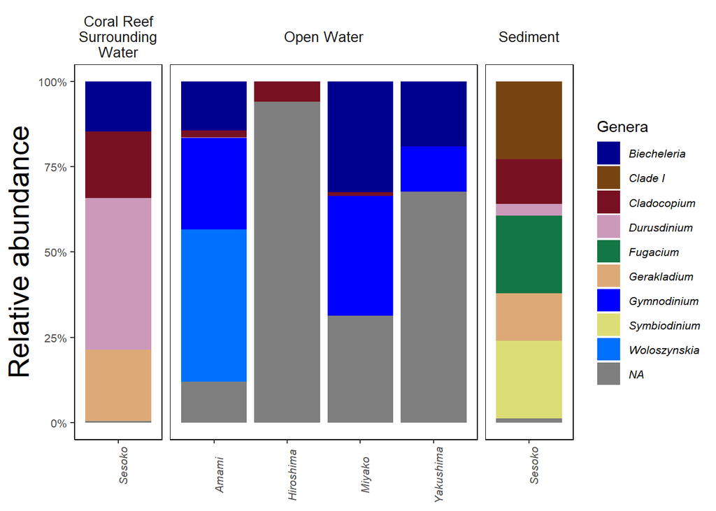

```r
filtered_dat$Type <- factor(filtered_dat$Type, levels = c("Open Water", "Coral Reef Surrounding Water", "Sediment")) #we order the sample types to better compare them in the composition plot

filtered_dat$Type <- str_wrap(filtered_dat$Type, width = 12) #this allows us to wrap long labels

fig2 <- filtered_dat %>%
  ggplot(aes(Location, proportion)) +
  facet_grid(~Type , scales = "free_x", space = "free_x")+
  geom_bar(aes (fill= Genus.x), stat = "identity", position = "fill", width = 0.9)+
  scale_fill_discrete(name = NULL)+
  scale_fill_manual(values= c("#00008F", "#774411", "#771122", "#CC99BB", "#117744", "#DDAA77", "#0000FF", "#DDDD77" , "#0070FF"), name = "Genera" )+
  scale_y_continuous(name = "Relative abundance",
                     labels = scales::percent) +
  labs(x = NULL)+
  my_theme_bar
fig2
```

```r
#fig2 <- ggsave("../figures/fig2.png", height = 4, width = 5, device= "png")
```

# Summary statitsics and pie charts

### feature count per sample

```r
dat %>% group_by(SampleID) %>%
  summarise(feature_count = sum(count)) %>%
  print(n=5)
```

```
## # A tibble: 44 × 2
##   SampleID feature_count
##   <chr>            <dbl>
## 1 Amami-D1           271
## 2 Amami-D2           369
## 3 Amami-D3          3746
## 4 Amami-D4           299
## 5 Amami-S1          4528
## # ℹ 39 more rows
```

### summarise data to calculate the abundance of each ASV

```r
ITS2_sum_by_species <- dat %>% select(Type, count, ITS2_types) %>%
  group_by(ITS2_types) %>%
  summarize(species_count = sum(count)) %>%
  mutate(species_percent = species_count/sum(species_count) * 100)

ITS2_sum_by_species
```

```
## # A tibble: 55 × 3
##    ITS2_types species_count species_percent
##    <chr>              <dbl>           <dbl>
##  1 " A2"                297          0.278
##  2 " C1"                243          0.227
##  3 " C1#"               283          0.265
##  4 " C1.v1a"           7062          6.61
##  5 " C115a"              95          0.0889
##  6 " C15.7"             691          0.647
##  7 " C1c.C45"          1650          1.54
##  8 " C33.1"              79          0.0739
##  9 " C3d_C21"           322          0.301
## 10 " C50"              2287          2.14
## # ℹ 45 more rows
```

## Create a Pie-Chart to complement the Composiiton plot wrapped by Type

### Lets make a new cleaned dataframe for a pichart

```r
dat_pie <- filtered_dat %>%
  arrange(desc(Genus.x))
```

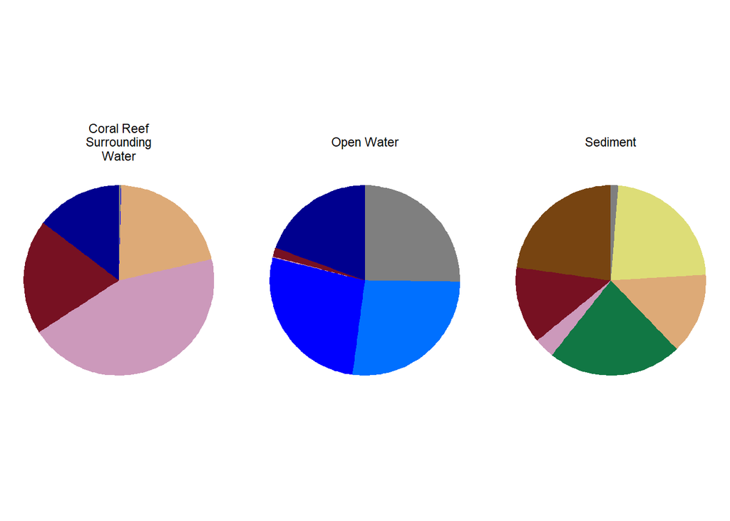

```r
fig2b <- filtered_dat %>%
  ggplot(aes("", proportion, fill = Genus.x )) +
  facet_wrap(~Type)+
  geom_bar(stat = "identity", position = "fill", width = 1)+
  coord_polar("y", start = 0)+
  #geom_text(aes(y= ypos), color = "white", size=6)+
  scale_fill_manual(values= c("#00008F", "#774411", "#771122", "#CC99BB",
                              "#117744", "#DDAA77", "#0000FF", "#DDDD77" , "#0070FF"),
                    name = "Genera" )+
  scale_y_continuous(name = "Relative abundance",
                     labels = scales::percent) +
  theme_void()+
  theme(legend.position = "none")

fig2b
```

```r
#fig2b <- ggsave("../figures/fig2b.png", height = 4, width = 5, device= "png")
```

# Multivariate test analysis

## PERMANOVA and betadisper on unweighted unifrac distance, we will first do a general test on all the samples to have an idea

### But we will later need to compare samples from open ocean and coral reef area separately.

```r
uwuni <- phyloseq::distance(physeq, method = "unifrac", weighted = FALSE)  #unweighted unifrac

sampleddf <- data.frame(sample_data(physeq))

adonis2(uwuni ~ Type * Region * Location , data = sampleddf)
```

```
## Permutation test for adonis under reduced model
## Terms added sequentially (first to last)
## Permutation: free
## Number of permutations: 999
##
## adonis2(formula = uwuni ~ Type * Region * Location, data = sampleddf)
##          Df SumOfSqs      R2      F Pr(>F)
## Type      2   2.8796 0.21378 6.1218  0.001 ***
## Region    2   1.0978 0.08150 2.3337  0.001 ***
## Location  1   0.5552 0.04122 2.3605  0.003 **
## Residual 38   8.9374 0.66351
## Total    43  13.4700 1.00000
## ---
## Signif. codes:  0 '***' 0.001 '**' 0.01 '*' 0.05 '.' 0.1 ' ' 1
```

## Now check for dispersion using betadisper since all our factors seem to be significant

###lets check type first

```r
betatype <- betadisper(uwuni, sampleddf$Type)
anova(betatype)
```

```
## Analysis of Variance Table
##
## Response: Distances
##           Df  Sum Sq  Mean Sq F value    Pr(>F)
## Groups     2 0.23519 0.117594   9.758 0.0003418 ***
## Residuals 41 0.49409 0.012051
## ---
## Signif. codes:  0 '***' 0.001 '**' 0.01 '*' 0.05 '.' 0.1 ' ' 1
```

## Sample type passed the dispersion test, check exactly where the diffrence is using tuckeyHSD test

```r
TukeyHSD(betatype)
```

```
##   Tukey multiple comparisons of means
##     95% family-wise confidence level
##
## Fit: aov(formula = distances ~ group, data = df)
##
## $group
##                                               diff         lwr        upr
## Open Water-Coral Reef Surrounding Water  0.2311577  0.10080398 0.36151143
## Sediment-Coral Reef Surrounding Water    0.1590443  0.01857099 0.29951763
## Sediment-Open Water                     -0.0721134 -0.16278854 0.01856174
##                                             p adj
## Open Water-Coral Reef Surrounding Water 0.0002870
## Sediment-Coral Reef Surrounding Water   0.0233088
## Sediment-Open Water                     0.1421005
```

### it looks like OO and CRSW are very diffreng and S and CRSW not so different, this could be becasue they were

### sampled from the same area and near coral reefs

## Do the same test for Location and Region

```r
betalocation <- betadisper(uwuni, sampleddf$Location)
anova(betalocation)
```

```
## Analysis of Variance Table
##
## Response: Distances
##           Df   Sum Sq   Mean Sq F value  Pr(>F)
## Groups     4 0.053658 0.0134146  2.8766 0.03518 *
## Residuals 39 0.181873 0.0046634
## ---
## Signif. codes:  0 '***' 0.001 '**' 0.01 '*' 0.05 '.' 0.1 ' ' 1
```

```r
adonis2(uwuni ~ Region, data = sampleddf)
```

```
## Permutation test for adonis under reduced model
## Terms added sequentially (first to last)
## Permutation: free
## Number of permutations: 999
##
## adonis2(formula = uwuni ~ Region, data = sampleddf)
##          Df SumOfSqs      R2      F Pr(>F)
## Region    3   3.2763 0.24323 4.2853  0.001 ***
## Residual 40  10.1937 0.75677
## Total    43  13.4700 1.00000
## ---
## Signif. codes:  0 '***' 0.001 '**' 0.01 '*' 0.05 '.' 0.1 ' ' 1
```

```r
betaregion <- betadisper(uwuni, sampleddf$Region)
anova(betaregion)
```

```
## Analysis of Variance Table
##
## Response: Distances
##           Df   Sum Sq   Mean Sq F value   Pr(>F)
## Groups     3 0.071679 0.0238930  5.1878 0.004023 **
## Residuals 40 0.184225 0.0046056
## ---
## Signif. codes:  0 '***' 0.001 '**' 0.01 '*' 0.05 '.' 0.1 ' ' 1
```

```r
TukeyHSD(betaregion)
```

```
##   Tukey multiple comparisons of means
##     95% family-wise confidence level
##
## Fit: aov(formula = distances ~ group, data = df)
##
## $group
##                                        diff         lwr         upr     p adj
## North Ryukyus-Central Ryukyus    0.03581111 -0.02669035  0.09831256 0.4262897
## Seto Inland Sea-Central Ryukyus -0.16229871 -0.29788341 -0.02671402 0.0134499
## Yaeyama-Central Ryukyus          0.01231684 -0.06497833  0.08961201 0.9734942
## Seto Inland Sea-North Ryukyus   -0.19810982 -0.33453929 -0.06168035 0.0020055
## Yaeyama-North Ryukyus           -0.02349427 -0.10226186  0.05527332 0.8542223
## Yaeyama-Seto Inland Sea          0.17461555  0.03080627  0.31842484 0.0119074
```

```r
TukeyHSD(betalocation)
```

```
##   Tukey multiple comparisons of means
##     95% family-wise confidence level
##
## Fit: aov(formula = distances ~ group, data = df)
##
## $group
##                             diff         lwr          upr     p adj
## Hiroshima-Amami     -0.157316446 -0.30996730 -0.004665595 0.0405962
## Miyako-Amami         0.017299107 -0.07758585  0.112184061 0.9846710
## Sesoko-Amami         0.004982269 -0.07473704  0.084701575 0.9997610
## Yakushima-Amami      0.013746354 -0.08466129  0.112154003 0.9944109
## Miyako-Hiroshima     0.174615552  0.02023978  0.328991326 0.0198007
## Sesoko-Hiroshima     0.162298714  0.01675184  0.307845589 0.0222688
## Yakushima-Hiroshima  0.171062800  0.01449719  0.327628410 0.0262150
## Sesoko-Miyako       -0.012316838 -0.09529132  0.070657647 0.9929465
## Yakushima-Miyako    -0.003552753 -0.10461542  0.097509914 0.9999758
## Yakushima-Sesoko     0.008764085 -0.07821681  0.095744980 0.9984270
```

### it lloks like seto inland sea/ Hiroshima is diffrent form other region

### Because our sampling was not even across regions,filter open ocean samples from environment to compare latitiude (Region)

```r
ps_filt_oo <- physeq %>%
  subset_samples(Type != "Sediment") %>%
  subset_samples(Type != "Coral Reef Surrounding Water") %>%
  subset_samples(sample_sums(physeq) > 0) %>%
  filter_taxa(function(x) sum(x) > 0, TRUE)
```

### Now create a ditance matrix and perform adonis2

```r
uwuni_env <- phyloseq::distance(ps_filt_oo, method = "unifrac", weighted = FALSE)
sampleddf_oo <- data.frame(sample_data(ps_filt_oo))
```

```r
adonis2(uwuni_env ~ Depth + Region , data = sampleddf_oo)
```

```
## Permutation test for adonis under reduced model
## Terms added sequentially (first to last)
## Permutation: free
## Number of permutations: 999
##
## adonis2(formula = uwuni_env ~ Depth + Region, data = sampleddf_oo)
##          Df SumOfSqs      R2      F Pr(>F)
## Depth     1   0.3002 0.04111 1.1184  0.303
## Region    2   1.0968 0.15019 2.0429  0.007 **
## Residual 22   5.9058 0.80870
## Total    25   7.3029 1.00000
## ---
## Signif. codes:  0 '***' 0.001 '**' 0.01 '*' 0.05 '.' 0.1 ' ' 1
```

## Depth is not significant but region/latitude is, check Region for within sample dispersion

```r
betaregion_oo <- betadisper(uwuni_env, sampleddf_oo$Region)
anova(betaregion_oo)
```

```
## Analysis of Variance Table
##
## Response: Distances
##           Df   Sum Sq  Mean Sq F value   Pr(>F)
## Groups     2 0.069793 0.034897  6.2619 0.006744 **
## Residuals 23 0.128176 0.005573
## ---
## Signif. codes:  0 '***' 0.001 '**' 0.01 '*' 0.05 '.' 0.1 ' ' 1
```

## Do a multivariate analysis of depth for samples collected from coral reeefs surrounding water and sediment

```r
ps_filt_crs <- physeq %>%
  subset_samples(Type != "Open Water") %>%
  subset_samples(sample_sums(physeq) > 0) %>%
  filter_taxa(function(x) sum(x) > 0, TRUE)
```

```r
uwuni_crs <- phyloseq::distance(ps_filt_crs, method = "unifrac", weighted = FALSE)
sampleddf_crs <- data.frame(sample_data(ps_filt_crs))
```

```r
adonis2(uwuni_crs ~ Type + Depth, data = sampleddf_crs)
```

```
## Permutation test for adonis under reduced model
## Terms added sequentially (first to last)
## Permutation: free
## Number of permutations: 999
##
## adonis2(formula = uwuni_crs ~ Type + Depth, data = sampleddf_crs)
##          Df SumOfSqs      R2      F Pr(>F)
## Type      1   0.7011 0.17578 3.9968  0.002 **
## Depth     1   0.6561 0.16449 3.7400  0.003 **
## Residual 15   2.6314 0.65972
## Total    17   3.9886 1.00000
## ---
## Signif. codes:  0 '***' 0.001 '**' 0.01 '*' 0.05 '.' 0.1 ' ' 1
```

## Since both Depth and Type are significant perform a betadispersion test

```r
betadepth_crs <- betadisper(uwuni_crs, sampleddf_crs$Depth)
anova(betadepth_crs)
```

```
## Analysis of Variance Table
##
## Response: Distances
##           Df   Sum Sq  Mean Sq F value Pr(>F)
## Groups     1 0.009658 0.009658  0.7895 0.3874
## Residuals 16 0.195733 0.012233
```

```r
betatype_crs <- betadisper(uwuni_crs, sampleddf_crs$Type)
anova(betatype_crs)
```

```
## Analysis of Variance Table
##
## Response: Distances
##           Df   Sum Sq  Mean Sq F value  Pr(>F)
## Groups     1 0.087761 0.087761  5.0202 0.03959 *
## Residuals 16 0.279704 0.017481
## ---
## Signif. codes:  0 '***' 0.001 '**' 0.01 '*' 0.05 '.' 0.1 ' ' 1
```

### There for type is more important here too. Depth did not pass our dispersion test

# Conclusion